# Report scores and DALI server

Esmeralda Garcia

11/5/2022

# **1. Tombusvirus prediction model**

Here I show some scores used for the evaluation of the model along the process of adding sequences gradually to the alignment. There are in total 10 alignments used to predict the 3D-structure of the protein QWC36212.1.

For this report there was loaded some needed packages.

```r
library(dplyr)
library(tidyr)
library(stringr)
library(DT)
library(ggplot2)
```

### Scores

#### Z-score

The z-score indicates overall model quality and measures the deviation of the total energy of the structure with respect to an energy distribution derived from random conformations (3,15). Z-scores outside a range characteristic for native proteins indicate erroneous structures. In order to facilitate interpretation of the z-score of the specified protein, its particular value is displayed in a plot that contains the z-scores of all experimentally determined protein chains in current PDB .

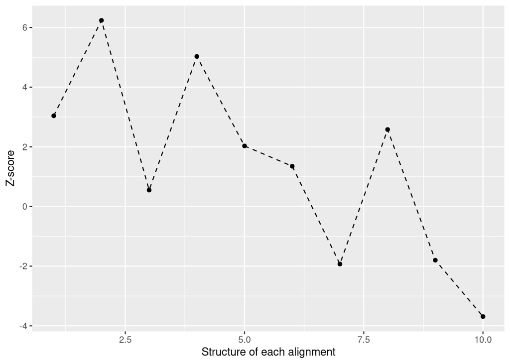

Evolution of Z-score along the progressive alignments

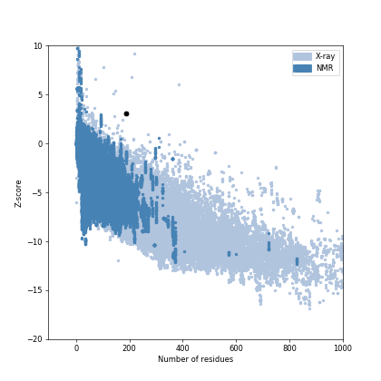

```r
scores <- read.csv("/home/esmeralda/Documentos/TFM/finalsteps/finalsteps/QWC36212.1_progression/stats/scores.csv")
ggplot(scores, aes(x=struct, y=zscore)) +
  geom_line(linetype = "dashed") + ylab("Z-score") + xlab("Structure of each alignment") +
  geom_point()
```

Representation of structural quality at global level of the structure predicted using the alignment 1 (Z-score between point cloud dispersion of this score with experimentally obtained structures).

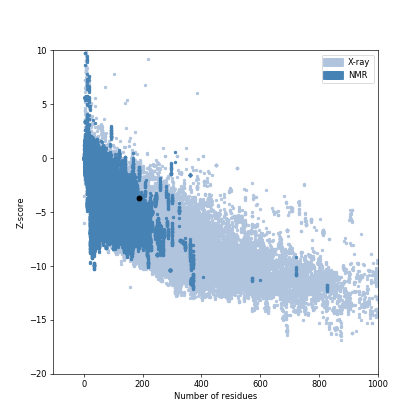

Representation of structural quality at global level of the structure predicted using the alignment 10 (Z-score between point cloud dispersion of this score with experimentally obtained structures).

#### Errat score

Analyzes the statistics of non-bonded interactions between different atom types and plots the value of the error function versus position of a 9-residue sliding window, calculated by a comparison with statistics from highly refined structures.

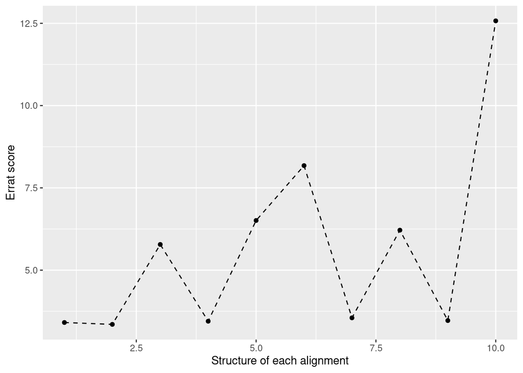

Evolution of Errat score along the progressive alignments

```r
ggplot(scores, aes(x=struct, y=errat)) +
  geom_line(linetype = "dashed") + ylab("Errat score") + xlab("Structure of each alignment") +
  geom_point()
```

#### MolProbity score

MolProbity score combines the clashscore, rotamer, and Ramachandran evaluations into a single score, normalized to be on the same scale as X-ray resolutio. Taking the MolProbity of the template and comparing them together will tell you if some residues have new critical errors.

Although the values seem to improve, they are still of very poor quality.

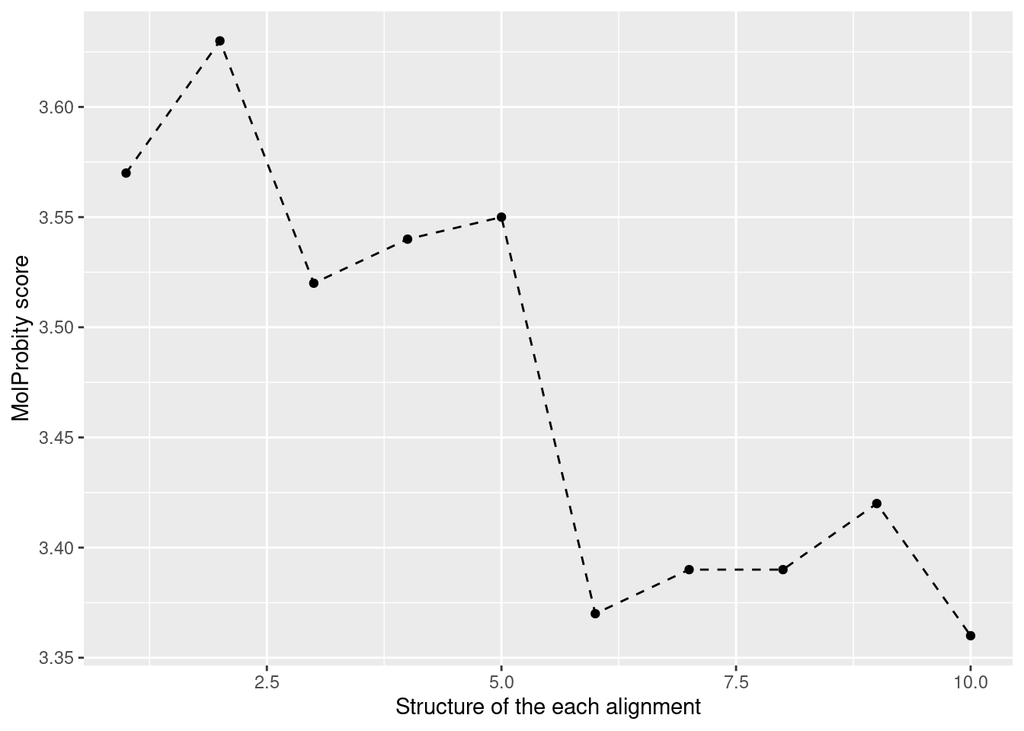

Evolution of MolProbity score along the progressive alignments

```r
ggplot(scores, aes(x=struct, y=molProbity)) +
  geom_line(linetype = "dashed") + ylab("MolProbity score") + xlab("Structure of the each alignment") +
  geom_point()
```

# **2. Search in DALI Server**

### Structures of DALI Server

I used the DALI server with two structures to see what protein data bank structures we could get. With the second one there are more viral sequences than with the obtained with the structure of the 7th alignment.

#### Alignment 7 structure

```r
dali_gemini <- read.csv("/home/esmeralda/Documentos/TFM/Dali prot_3_3A2_gemini.csv")
dali_gemini$X <- NULL

#' @title
#' URL's from PDB identifiers
#' @description
#' It makes the url's from PDB identifiers
#' @param id PDB identifiers
#' @return
#' The corresponding URL's in the database
#' @export
#' @family URL generation
pdb2url = function(id)
  ifelse(id == "NA",NA,
         paste("<a href='https://www.rcsb.org/structure/",
               id," 'target='_blank' >",id,"</a>",sep=""))

dali_gemini$Structure <- pdb2url(dali_gemini[, "Structure"])
DT::datatable(dali_gemini, rownames = NULL,
              options = list(
                pageLength = 20,
                order = list(list(2, "desc"),list(3, "asc"))),
              caption = "Table 1. Summary of results of Dali Server",
              escape = FALSE
              )
```

| Structure | Chain | Z | rmsd | lali | nres | X.id | Description | Species |
| --- | --- | --- | --- | --- | --- | --- | --- | --- |
| 6cpd | A | 5.6 | 3.1 | 99 | 126 | 8 | PMOD | Methylocystis sp. |
| 6cpd | B | 5.5 | 3.2 | 100 | 127 | 8 | PMOD | Methylocystis sp. |
| 6ld6 | C | 5.4 | 3.2 | 109 | 620 | 5 | LACZ1 BETA-GALACTOSIDASE | Bifidobacterium dentium |
| 5f0l | B | 5.3 | 3.7 | 110 | 294 | 9 | VACUOLAR PROTEIN SORTING-ASSOCIATED PROTEIN 35 | Homo sapiens |
| 6dxu | C | 5.2 | 3.6 | 110 | 806 | 5 | GLYCOSYL HYDROLASE FAMILY 2, TIM BARREL DOMAIN PR | Parabacteroides merdae |
| 7blo | J | 5.2 | 3.9 | 110 | 294 | 12 | VACUOLAR PROTEIN SORTING-ASSOCIATED PROTEIN 26A | Homo sapiens |
| 6d7j | B | 5.2 | 3.9 | 118 | 788 | 4 | BETA-GLUCURONIDASE | Parabacteroides merdae |
| 7blo | F | 5.2 | 3.9 | 109 | 294 | 12 | VACUOLAR PROTEIN SORTING-ASSOCIATED PROTEIN 26A | Homo sapiens |
| 6dxu | B | 5.2 | 3.8 | 112 | 803 | 4 | GLYCOSYL HYDROLASE FAMILY 2, TIM BARREL DOMAIN PR | Parabacteroides merdae |
| 6qub | B | 5.2 | 3.7 | 111 | 857 | 5 | BETA-GALACTOSIDASE | Bifidobacterium bifidum |

[output cut: 989 more lines]

##### **Viral results**

```r
virus <- dplyr::filter(dali_gemini, grepl('virus', Species))

DT::datatable(virus, rownames = NULL,
              options = list(
                pageLength = 20,
                order = list(list(2, "desc"),list(3, "asc"))),
              caption = "Table 1. Summary of results of Dali Server",
              escape = FALSE
              )
```

| Structure | Chain | Z | rmsd | lali | nres | X.id | Description | Species |
| --- | --- | --- | --- | --- | --- | --- | --- | --- |
| 3bes | R | 4 | 3.1 | 85 | 250 | 5 | INTERFERON GAMMA | Ectromelia virus |
| 4ow5 | A | 3.9 | 4.6 | 105 | 307 | 10 | FUSOLIN | unidentified entomopoxvirus |

#### Alignment 10 (all) structure

```r
dali_MP_all <- read.csv("/home/esmeralda/Documentos/TFM/Dali prot_3_MP_all.csv")
dali_MP_all$X <- NULL

dali_MP_all$Structure <- pdb2url(dali_MP_all[, "Structure"])
DT::datatable(dali_MP_all, rownames = NULL,
              options = list(
                pageLength = 20,
                order = list(list(2, "desc"),list(3, "asc"))),
              caption = "Table 1. Summary of results of Dali Server",
              escape = FALSE
              )
```

| Structure | Chain | Z | rmsd | lali | nres | X.id | Description | Species |
| --- | --- | --- | --- | --- | --- | --- | --- | --- |
| 5gka | A | 6.7 | 3.5 | 114 | 253 | 8 | CAPSID PROTEIN VP1 | Aichi virus |
| 1za7 | A | 6.5 | 3.3 | 120 | 151 | 11 | COAT PROTEIN | Cowpea chlorotic |
| 1cwp | A | 6.5 | 3.4 | 121 | 149 | 11 | COAT PROTEIN |  |
| 6cv3 | A | 6.5 | 3.6 | 122 | 224 | 7 | VIRAL PROTEIN 1 | Enterovirus D68 |
| 6wpx | B | 6.4 | 4.2 | 122 | 451 | 11 | BLEST2 | Bacillus licheniformis |
| 6wpx | A | 6.4 | 3.9 | 119 | 450 | 9 | BLEST2 | Bacillus licheniformis |
| 6hbj | B | 6.4 | 3.6 | 116 | 237 | 4 | VIRAL PROTEIN 1 | Echovirus E18 |
| 3afg | B | 6.3 | 2.9 | 96 | 507 | 11 | SUBTILISIN-LIKE SERINE PROTEASE | Thermococcus kodakarensis |
| 3afg | A | 6.3 | 3 | 95 | 505 | 12 | SUBTILISIN-LIKE SERINE PROTEASE | Thermococcus kodakarensis |
| 5lvc | a | 6.3 | 3.3 | 110 | 205 | 8 | VP1 | Aichi virus |

[output cut: 989 more lines]

##### **Viral results**

```r
virus <- dplyr::filter(dali_MP_all, grepl('virus', Species))

DT::datatable(virus, rownames = NULL,
              options = list(
                pageLength = 20,
                order = list(list(2, "desc"),list(3, "asc"))),
              caption = "Table 1. Summary of results of Dali Server",
              escape = FALSE
              )
```

| Structure | Chain | Z | rmsd | lali | nres | X.id | Description | Species |
| --- | --- | --- | --- | --- | --- | --- | --- | --- |
| 5gka | A | 6.7 | 3.5 | 114 | 253 | 8 | CAPSID PROTEIN VP1 | Aichi virus |
| 6cv3 | A | 6.5 | 3.6 | 122 | 224 | 7 | VIRAL PROTEIN 1 | Enterovirus D68 |
| 6hbj | B | 6.4 | 3.6 | 116 | 237 | 4 | VIRAL PROTEIN 1 | Echovirus E18 |
| 5lvc | a | 6.3 | 3.3 | 110 | 205 | 8 | VP1 | Aichi virus |
| 6cv4 | A | 6.1 | 3.7 | 123 | 225 | 7 | VIRAL PROTEIN 1 | Enterovirus D68 |
| 6cs3 | A | 6 | 3.6 | 121 | 267 | 7 | VIRAL PROTEIN 1 | Enterovirus D68 |
| 6csg | A | 5.9 | 3.7 | 126 | 289 | 6 | VIRAL PROTEIN 1 | Enterovirus D68 |
| 6csh | A | 5.9 | 3.7 | 123 | 202 | 7 | VIRAL PROTEIN 1 | Enterovirus D68 |
| 6crs | A | 5.9 | 3.8 | 126 | 212 | 6 | VIRAL PROTEIN 1 | Enterovirus D68 |
| 6gv4 | B | 5.8 | 3.9 | 112 | 195 | 9 | RNA (5'-R(*UP*GP*GP*UP*AP*UP*UP*U)-3') | Human parechovirus |

[output cut: 443 more lines]

### TOP 10 - Structure of alignment 10

**The majority of the viral hits are related to coat/capsid proteins (with jelly-roll fold) which are assemblied to be part of multimer protein complexes.**

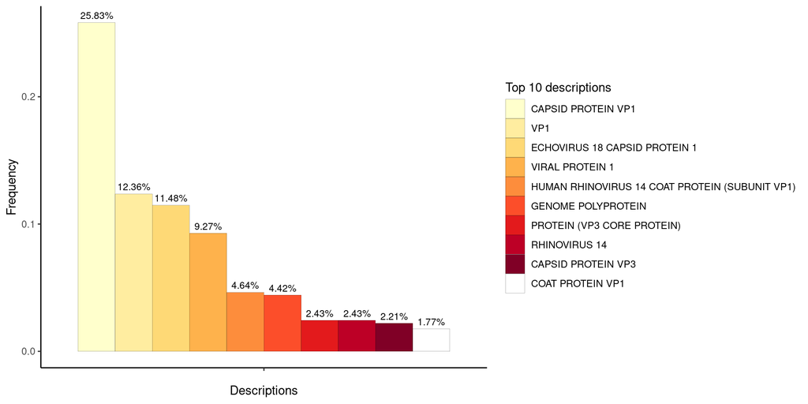

Top 10 descriptions whose proteins were hit in the search in Dali Server

```r
top <- data.frame(sort(table(virus$Description), decreasing=TRUE)[1:10])

colors = c("#facba6", "#f59e72")
colors = c("#a8dbd9", "#008080")
mycolors <- colorRampPalette(c("#facba6", "#008080"))(10)
ggplot(top, aes(x="", y = Freq/nrow(virus), fill=Var1, label = scales::percent((Freq/nrow(virus))))) +
  geom_bar(stat="identity", position = "dodge", colour="black", size=0.05, width=1) +
  guides(fill=guide_legend(title="Top 10 descriptions")) +
  scale_fill_brewer(palette = "YlOrRd") +
  geom_text(position = position_dodge(width = 1),    # move to center of bars
              vjust = -0.5,    # nudge above top of bar
              size = 3) + theme_classic() + ylab("Frequency") + xlab("Descriptions")
```

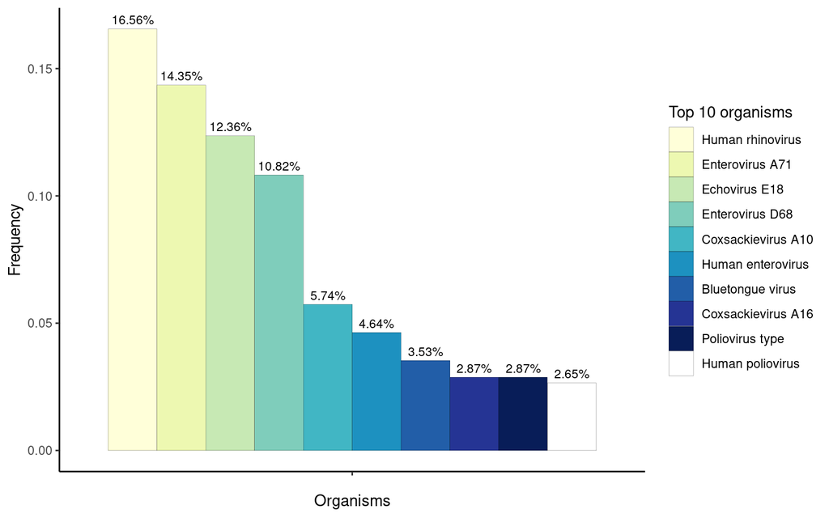

Top 10 organisms whose proteins were hit in the search in Dali Server

```r
top <- data.frame(sort(table(virus$Species), decreasing=TRUE)[1:10])

ggplot(top, aes(x="", y = Freq/nrow(virus), fill=Var1, label = scales::percent((Freq/nrow(virus))))) +
  geom_bar(stat="identity", position = "dodge", colour="black", size=0.05, width=1) +
  guides(fill=guide_legend(title="Top 10 organisms")) +
  scale_fill_brewer(palette = "YlGnBu") +
  geom_text(position = position_dodge(width = 1),    # move to center of bars
              vjust = -0.5,    # nudge above top of bar
              size = 3) + theme_classic() + ylab("Frequency") + xlab("Organisms")
```